# PeerAssessment1

A. E. Bodden

Saturday, February 14, 2015

### Read the activity.csv and produce a histogram of steps taken per day

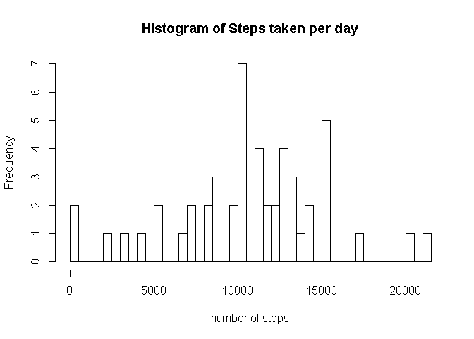

```r
library(knitr)
rdata <- read.csv("activity.csv",header=T,sep=",")
xdata = aggregate(steps ~ date, data=rdata, FUN = sum )
hist(xdata$steps, xlab= "number of steps", main = "Histogram of Steps taken per day", breaks = 60)
```

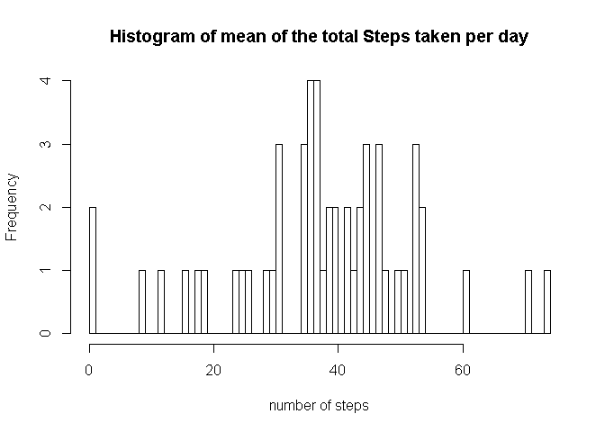

```r
meandata = aggregate(steps ~ date, data=rdata, FUN = mean )
hist(meandata$steps, xlab= "number of steps", main = "Histogram of mean of the total Steps taken per day", breaks = 60)
```

```r
meandata
```

```
##          date      steps
## 1  2012-10-02  0.4375000
## 2  2012-10-03 39.4166667
## 3  2012-10-04 42.0694444
## 4  2012-10-05 46.1597222
## 5  2012-10-06 53.5416667
## 6  2012-10-07 38.2465278
## 7  2012-10-09 44.4826389
## 8  2012-10-10 34.3750000
## 9  2012-10-11 35.7777778
## 10 2012-10-12 60.3541667
## 11 2012-10-13 43.1458333
## 12 2012-10-14 52.4236111
## 13 2012-10-15 35.2048611
## 14 2012-10-16 52.3750000
```

[output cut: 39 more lines]

[figure not shown]

```r
mediandata = aggregate(steps ~ date, data=rdata, FUN = median )
hist(mediandata$steps, xlab= "number of steps", main = "Histogram of the median of the Steps taken per day", breaks = 60)
```

```r
mediandata
```

```
##          date steps
## 1  2012-10-02     0
## 2  2012-10-03     0
## 3  2012-10-04     0
## 4  2012-10-05     0
## 5  2012-10-06     0
## 6  2012-10-07     0
## 7  2012-10-09     0
## 8  2012-10-10     0
## 9  2012-10-11     0
## 10 2012-10-12     0
## 11 2012-10-13     0
## 12 2012-10-14     0
## 13 2012-10-15     0
## 14 2012-10-16     0
```

[output cut: 39 more lines]

### Show the average steps per 5 minute interval across all days

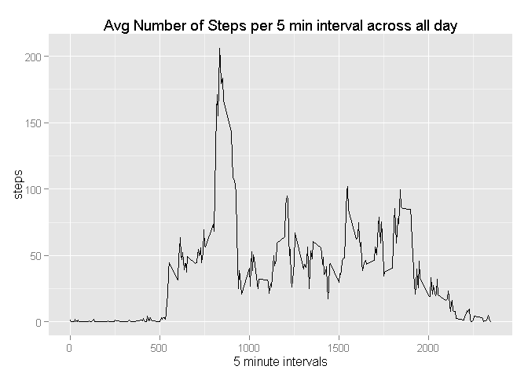

```r
library(ggplot2)
xydata = aggregate(steps ~ interval, data=rdata, FUN = mean )
qplot(x=interval, y=steps, data=xydata, geom = "path", xlab= "5 minute intervals", main = "Avg Number of Steps per 5 min interval across all day")
```

### Which 5-minute interval, on average across all the days in the dataset, contains the maximum number of steps?

```r
maxavgstepinterval <-xydata$interval[order(xydata$steps, decreasing=T)[1]]
maxavgstepct <-xydata$steps[order(xydata$steps, decreasing=T)[1]]
```

The 5 minute interval of 835, has the maximun average number of steps at 206.1698113.

### Calculate and report the total number of missing values in the dataset (i.e. the total number of rows with NAs)

```r
totnarows <-sum(is.na(rdata$steps))
```

The total number of rows that have an “na” value are 2304.

#### Devise a strategy for filling in all of the missing values in the dataset. The strategy does not need to be sophisticated. For example, you could use the mean/median for that day, or the mean for that 5-minute interval, etc.

#### Create a new dataset that is equal to the original dataset but with the missing data filled in.

```r
suppressWarnings(1)
```

```
## [1] 1
```

```r
fixedrdata <- rdata
xend <- 1:length(rdata$steps)
for(i in seq(xend)){
    if(is.na(rdata$steps[i])) {
        ind <- grep(rdata$interval[i],xydata$interval)
        fixedrdata$steps[i] <- xydata$steps[ind]
     }
}
```

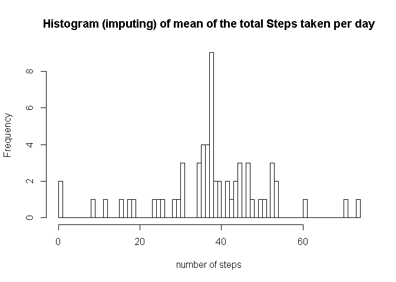

```r
meandata = aggregate(steps ~ date, data=fixedrdata, FUN = mean )
hist(meandata$steps, xlab= "number of steps", main = "Histogram (imputing) of mean of the total Steps taken per day", breaks = 60)
```

```r
meandata
```

```
##          date      steps
## 1  2012-10-01 37.3825996
## 2  2012-10-02  0.4375000
## 3  2012-10-03 39.4166667
## 4  2012-10-04 42.0694444
## 5  2012-10-05 46.1597222
## 6  2012-10-06 53.5416667
## 7  2012-10-07 38.2465278
## 8  2012-10-08 37.3825996
## 9  2012-10-09 44.4826389
## 10 2012-10-10 34.3750000
## 11 2012-10-11 35.7777778
## 12 2012-10-12 60.3541667
## 13 2012-10-13 43.1458333
## 14 2012-10-14 52.4236111
```

[output cut: 47 more lines]

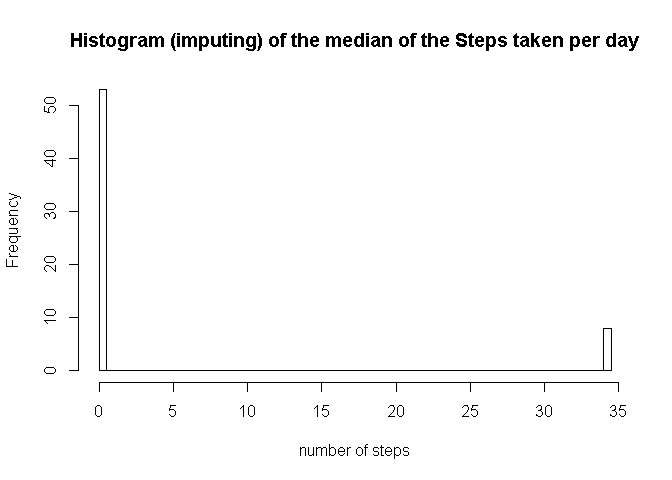

```r
mediandata = aggregate(steps ~ date, data=fixedrdata, FUN = median )
hist(mediandata$steps, xlab= "number of steps", main = "Histogram (imputing) of the median of the Steps taken per day", breaks = 60)
```

```r
mediandata
```

```
##          date    steps
## 1  2012-10-01 34.11321
## 2  2012-10-02  0.00000
## 3  2012-10-03  0.00000
## 4  2012-10-04  0.00000
## 5  2012-10-05  0.00000
## 6  2012-10-06  0.00000
## 7  2012-10-07  0.00000
## 8  2012-10-08 34.11321
## 9  2012-10-09  0.00000
## 10 2012-10-10  0.00000
## 11 2012-10-11  0.00000
## 12 2012-10-12  0.00000
## 13 2012-10-13  0.00000
## 14 2012-10-14  0.00000
```

[output cut: 47 more lines]

### Show the average steps per 5 minute interval across all days

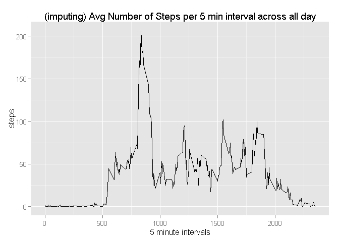

```r
library(ggplot2)
xydata = aggregate(steps ~ interval, data=fixedrdata, FUN = mean )
qplot(x=interval, y=steps, data=xydata, geom = "path", xlab= "5 minute intervals", main = "(imputing) Avg Number of Steps per 5 min interval across all day")
```

### Which 5-minute interval, on average across all the days in the dataset, contains the maximum number of steps?

```r
maxavgstepinterval <-xydata$interval[order(xydata$steps, decreasing=T)[1]]
maxavgstepct <-xydata$steps[order(xydata$steps, decreasing=T)[1]]
```

The 5 minute interval of 835, has the maximun average number of steps at 206.1698113.

### Calculate and report the total number of missing values in the dataset (i.e. the total number of rows with NAs)

```r
totnarows <-sum(is.na(fixedrdata$steps))
```

The total number of rows that have an “na” value are 0.

[figure not shown]

```r
fixedrdata$wd <- as.factor(weekdays(as.Date(fixedrdata$date)))

levels(fixedrdata$wd) <- c("weekday","weekday","weekday","weekday","weekday","weekend","weekend")
xydata = fixedrdata
xydata = aggregate(steps ~ interval + wd, data=fixedrdata, FUN = mean )
qplot(x=interval, y=steps, data=xydata, geom = "path", xlab= "5 minute intervals", main = "(imputing) Avg Number of Steps per 5 min interval across all day",facets = wd~.)
```